# Análise Alternativa de uma Replicação – IAT

Renan Carneiro Barbosa de Araújo

2025-06-07

# Introdução

Este relatório examina dados de um experimento IAT (Implicit Association Test) com foco nas diferenças médias entre os sexos. No IAT, valores maiores indicam associação com artes e menor associação com matemática. Níveis de viés:  
- Pequeno: 0.15  
- Médio: 0.35  
- Grande: 0.65

# Leitura dos dados

```r
iat <- read_csv(here::here(params$arquivo_dados), col_types = "cccdc") %>%
  mutate(sex = factor(sex, levels = c("m", "f"), ordered = TRUE))
glimpse(iat)
```

```
## Rows: 155
## Columns: 5
## $ session_id  <chr> "2436706", "2436967", "2440429", "2440430", "2440431", "24…
## $ referrer    <chr> "sdsu", "sdsu", "sdsu", "sdsu", "sdsu", "sdsu", "sdsu", "s…
## $ sex         <ord> f, f, f, f, m, f, f, m, f, m, f, f, f, f, f, f, m, m, f, m…
## $ d_art       <dbl> 0.90444320, -0.47402625, 0.46840862, -0.02522412, 0.136813…
## $ iat_exclude <chr> "Include", "Include", "Include", "Include", "Include", "In…
```

# Distribuição dos escores IAT por sexo

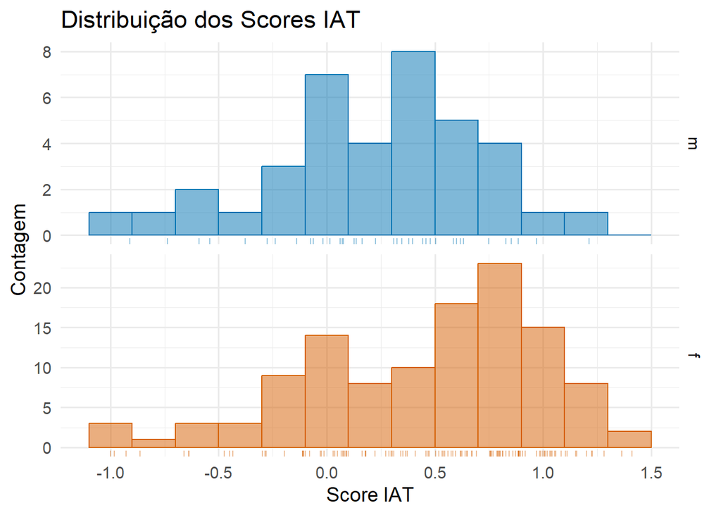

```r
iat %>%
  ggplot(aes(x = d_art, fill = sex, color = sex)) +
  geom_histogram(binwidth = .2, alpha = 0.5, position = "identity") +
  geom_rug(alpha = 0.4) +
  facet_grid(sex ~ ., scales = "free_y") +
  scale_fill_manual(values = c("#0072B2", "#D55E00")) +
  scale_color_manual(values = c("#0072B2", "#D55E00")) +
  labs(x = "Score IAT", y = "Contagem", title = "Distribuição dos Scores IAT") +
  theme(legend.position = "none")
```

# Visualização dos escores por sexo

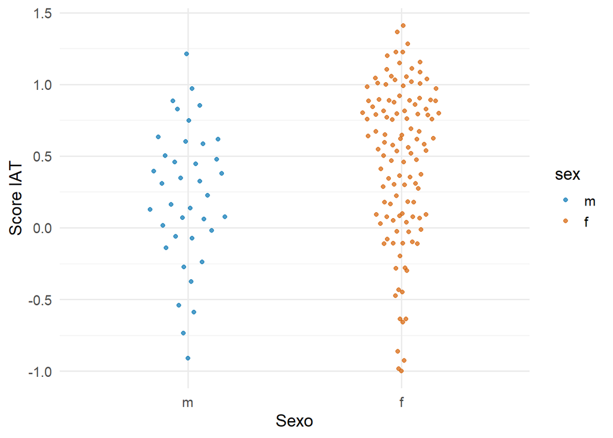

```r
iat %>%
  ggplot(aes(x = sex, y = d_art, color = sex)) +
  geom_quasirandom(width = 0.2, alpha = 0.7) +
  scale_color_manual(values = c("#0072B2", "#D55E00")) +
  labs(x = "Sexo", y = "Score IAT")
```

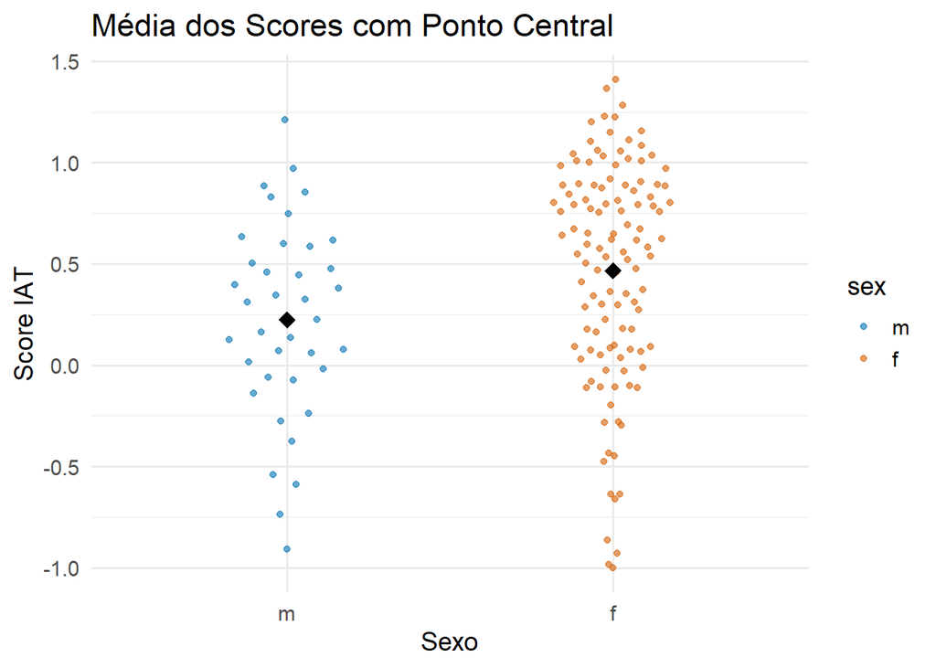

```r
iat %>%
  ggplot(aes(x = sex, y = d_art, color = sex)) +
  geom_quasirandom(width = 0.2, alpha = 0.6) +
  stat_summary(fun = mean, geom = "point", color = "black", size = 4, shape = 18) +
  scale_color_manual(values = c("#0072B2", "#D55E00")) +
  labs(x = "Sexo", y = "Score IAT", title = "Média dos Scores com Ponto Central")
```

# Estatísticas Resumidas

```r
iat %>%
  group_by(sex) %>%
  summarise(
    media = mean(d_art),
    desvio = sd(d_art),
    n = n()
  )
```

| sex | media | desvio | n |
| --- | --- | --- | --- |
| m | 0.2236359 | 0.4850899 | 38 |
| f | 0.4666898 | 0.5475448 | 117 |

```r
agrupado <- iat %>%
  group_by(sex) %>%
  summarise(media = mean(d_art))
m <- agrupado %>% filter(sex == "m") %>% pull(media)
f <- agrupado %>% filter(sex == "f") %>% pull(media)
m - f
```

```
## [1] -0.2430539
```

# Intervalo de Confiança (bootstrap)

```r
theta <- function(d, i) {
  temp <- d %>% slice(i) %>% group_by(sex) %>% summarise(media = mean(d_art))
  m <- temp %>% filter(sex == "m") %>% pull(media)
  f <- temp %>% filter(sex == "f") %>% pull(media)
  m - f
}

booted <- boot(data = iat, statistic = theta, R = 2000)

ci <- tidy(booted, conf.level = 0.95, conf.method = "bca", conf.int = TRUE)
ci
```

| statistic | bias | std.error | conf.low | conf.high |
| --- | --- | --- | --- | --- |
| -0.2430539 | -0.003057514 | 0.09176387 | -0.4310941 | -0.06882336 |

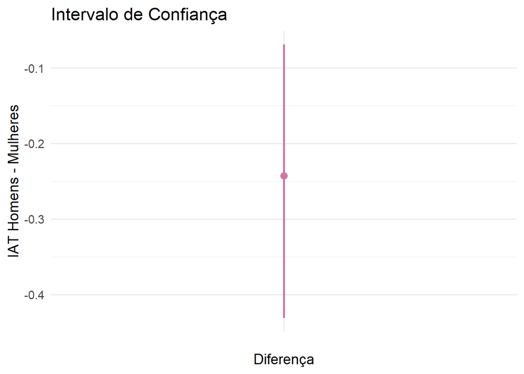

```r
ci %>%
  ggplot(aes(x = "", y = statistic, ymin = conf.low, ymax = conf.high)) +
  geom_pointrange(color = "#CC79A7", linewidth = 1) +
  geom_point(size = 3, color = "#CC79A7") +
  labs(x = "Diferença", y = "IAT Homens - Mulheres", title = "Intervalo de Confiança")
```

# Comparação visual conjunta

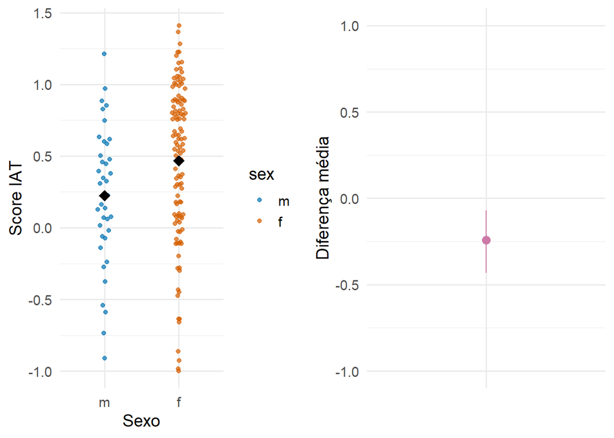

```r
p1 <- iat %>%
  ggplot(aes(x = sex, y = d_art, color = sex)) +
  geom_quasirandom(width = .1, alpha = 0.7) +
  stat_summary(fun = mean, geom = "point", color = "black", size = 4, shape = 18) +
  scale_color_manual(values = c("#0072B2", "#D55E00")) +
  labs(x = "Sexo", y = "Score IAT")

p2 <- ci %>%
  ggplot(aes(x = "", y = statistic, ymin = conf.low, ymax = conf.high)) +
  geom_pointrange(color = "#CC79A7") +
  geom_point(size = 3, color = "#CC79A7") +
  ylim(-1, 1) +
  labs(x = "", y = "Diferença média")

grid.arrange(p1, p2, ncol = 2)
```

# Conclusão

# Bootstrap Manual – Simple Percentile Method

```r
simple_percentile_bootstrap_ci <- function(data, metric_function, alpha = 0.05, n_bootstrap = 2000) {
  bootstrap <- function(data, n) {
    indices <- sample(nrow(data), replace = TRUE, size = n)
    data %>% slice(indices)
  }

  bootstrap_results <- replicate(n_bootstrap, metric_function(bootstrap(data, nrow(data))))

  lower <- quantile(bootstrap_results, alpha / 2)
  upper <- quantile(bootstrap_results, 1 - alpha / 2)

  list(results = bootstrap_results, ci = c(lower, upper))
}

diff_mf <- function(d) {
  agrupado <- d %>% group_by(sex) %>% summarise(media = mean(d_art))
  m <- agrupado %>% filter(sex == "m") %>% pull(media)
  f <- agrupado %>% filter(sex == "f") %>% pull(media)
  m - f
}

rb <- simple_percentile_bootstrap_ci(iat, diff_mf)
rb$ci
```

```
##        2.5%       97.5%
## -0.41816363 -0.05922425
```

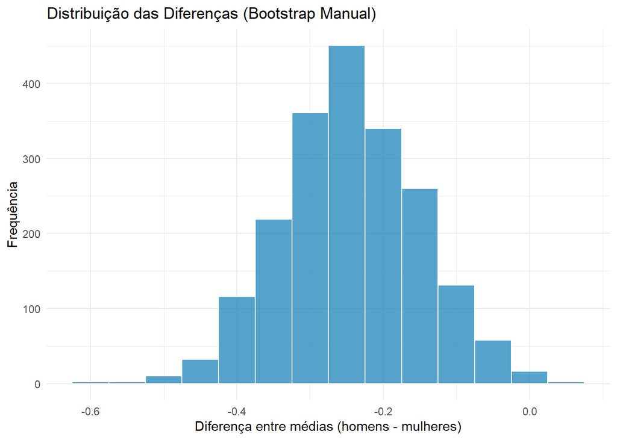

```r
# Histograma dos valores bootstrap manuais
data.frame(value = rb$results) %>%
  ggplot(aes(x = value)) +
  geom_histogram(binwidth = 0.05, fill = "#2b8cbe", color = "white", alpha = 0.8) +
  labs(title = "Distribuição das Diferenças (Bootstrap Manual)",
       x = "Diferença entre médias (homens - mulheres)",
       y = "Frequência") +
  theme_minimal()
```

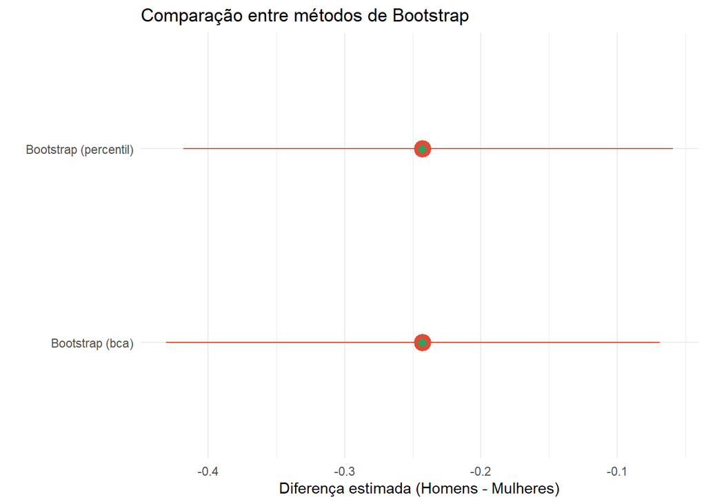

```r
# Gráfico comparativo das estimativas e ICs das duas abordagens
library(dplyr)

comparativo <- bind_rows(
  ci %>% mutate(metodo = "Bootstrap (bca)"),
  tibble(
    statistic = diff_mf(iat),
    conf.low = rb$ci[1],
    conf.high = rb$ci[2],
    metodo = "Bootstrap (percentil)"
  )
)

comparativo %>%
  ggplot(aes(x = metodo, y = statistic, ymin = conf.low, ymax = conf.high)) +
  geom_pointrange(color = "#e34a33", size = 1.2) +
  geom_point(size = 3, shape = 18, color = "#2ca25f") +
  coord_flip() +
  labs(title = "Comparação entre métodos de Bootstrap",
       x = "",
       y = "Diferença estimada (Homens - Mulheres)") +
  theme_minimal()
```

## Resultados e Discussões

Ambos os métodos de bootstrapping (BCA e Percentil Simples) fornecem estimativas muito próximas para a diferença média de escores IAT entre homens e mulheres.

As conclusões permanecem consistentes: em média, mulheres apresentam uma associação implícita mais forte com artes (ou seja, negativa com matemática) do que homens.

Apesar de pequenas variações nos limites inferiores e superiores dos intervalos de confiança, ambos os métodos sugerem uma diferença real e estatisticamente significativa entre os grupos.

O método do percentil simples, embora mais fácil de implementar, não oferece as correções de viés e assimetria presentes no BCA. Ainda assim, neste caso, ambos se alinham bastante, indicando robustez na estimativa da diferença de médias.